# Explore

Aparna Nayak

11/9/2020

# Section 1

# Descriptive statistics

**Explain which types of descriptive summary statistic and visualization are most appropriate for each type of statistical measure**

There are 3 types of descriptive summary statistic. They are measure of frequency, measure of central tendency and measure of dispersion/variation.

**Frequency** can be be measured either using count or using percentage.

EXAMPLE: Let us assume that the variable of interest is whether a person lives in urban area or rural area. The outcome of the variable would be urban or rural. In such cases, we can report frequency and percentage as a measure.

**Central tendency** is appropriate to describe numerical data. This is representative value around which all the numbers in the set tend to cluster. There are three measures to describe the central tendency. They are mode, median, and mean.

Mode is the value that occurs most frequently for a variable in a set of data. This is not a good measure when there is same frequency for all unique elements in the set. A set can have multiple modes when more than one element has the highest frequency.

Median is middle value of a sequence of all the values in a distribution arranged from lowest to highest when the set has odd number of elements. In case, the set has even number of elements, the median is the average of the middle two elements after they are arranged in an ascending order.

Mean is arithmetic average of a group of values.

**Dispersion/Variability** is used to measure how the values of a variable are spread. This helps us identify whether all the values of a variable are clustered close together. Usual and unusual values can be identified using measure of variability.

Range is simplest numeric measure of variability. This can be used when a variable has upper threshold or lower threshold(or both) that should not be crossed. For example, age of a person, born month of a person etc.

Variance is used to measure how the data is deviated from the mean. This can be calculated as average of the squares of the differences from the mean.

Standard deviation is square root of the variance. This value is always greater than zero. Only if all the elements are same then the standard deviation is zero.

Interquartile range is the range of the middle half of the data. It allows to understand the distribution of values within the set.

EXAMPLE: Consider a set that indicates age of all the players of the cricket team.

Age: 23, 28, 23, 24, 23, 26, 24, 21, 23, 25, 27

Mode : The mode is the number that is repeated more often than any other, hence, 23 is the mode.

Median : 21, 23, 23, 23, 23, 24, 24, 25, 26, 27, 28

The dataset has 11 numbers. (11+1)/2 i.e. 6th number is median i.e. 24 Mean: (21+ 23+ 23+23+ 23+ 24+ 24+ 25+ 26+ 27+ 28) / 11 = 24.27

Mean of the age is 24.27

Range of the variable age is 21-28

Variance is 4.22. It is computed by subtracting every observation with mean and taking the square of it. All the values are summed up and the final total is divided by divided by degrees of freedom.

Standard deviation is 2.05. This is squareroot of the variance.

```r
x<-c(23, 28, 23, 24, 23, 26, 24, 21, 23, 25, 27)

meanX <- mean(x)
cat("Mean is",round(meanX,2),"\n")
```

```
## Mean is 24.27
```

```r
getMode <- function(v) {
   uniqv <- unique(v)
   uniqv[which.max(tabulate(match(v, uniqv)))]
}  #ref: https://www.tutorialspoint.com/r/r_mean_median_mode.htm

modeX <- getMode(x)
cat("Mode is",modeX,"\n")
```

```
## Mode is 23
```

```r
medianX <- median(x)
cat("Median is",medianX,"\n")
```

```
## Median is 24
```

```r
cat("Range is",range(x),"\n")
```

```
## Range is 21 28
```

```r
cat("Variance is",round(var(x),2),"\n")
```

```
## Variance is 4.22
```

```r
cat("Standard deviation is",round(sd(x),2),"\n")
```

```
## Standard deviation is 2.05
```

**Appropriate graph for statistic:**  
Interval/Ratio (normally distributed) - Mean & std deviation - Histogram

Interval/Ratio (skewed/kurtosis) - Median & IQR - Histogram / Box plot

Nominal/Ordinal data - Mode & simple frequencies - Bar charts / Pie charts / Frequency tables.

# Section 2

**Assessing a variable for normality**

To understand about the distribution the variable is following, as a analyst we need to follow following steps.

- Inspect the data
- Generate descriptive statistics
- Generate visuals
- Make decision about normality

The following graphs help to assess a variable for normality.

- Histogram
- QQ plot
- Boxplot (helps to identify skewness and kurtosis)

Histogram is a graphical display of distribution of a numeric variable. Horizontal axis represents possible values of the variable. Vertical axis represents frequency or relative frequency. Horizontal axis can be divided into smaller chunks and are called as ‘bins’. These bins can be used to represent continuous values. If the graph is bell-shaped, single peaked and symmetrical around the centre we can conclude that graph is normally distributed. We can draw density curve over histogram to understand overall pattern of a distribution. A distribution is normal if its density curve is symmetric, single peaked and bell shaped.

QQ plot is a scatter plot created by plotting two sets of quantiles against one another. If both sets of quantiles come from the same distribution, the points roughly form a straight line.

Boxplot is a graphical display that describes the properties of a numeric variable using quartiles. This plot is usually used when we need to compare multiple numerical variables and need to point out at the outliers. In case of normal distribution, the box will be symmetrical with the mean and median in the center with some outliers. Skewness can be clearly identified when the graph is shrink towards either upper half or lower half. Wider spread of box means data is kurtosis.

Usually, a standard normal distribution has mean ‘0’ and standard deviation ‘1’. Histogram makes use of measure of central tendency (mean and median) to describe the normality of the data. Density curves that are bell-shaped, single peaked and symmetrical around the centre are said to follow normal distribution.

When it is difficult to assess the variable for normality using histogram and QQ-plot, standardized scores for skewness value between +/-2 are considered for acceptable in order to prove normal univariate distribution. When the values does not fall in the standard acceptance range of skewness, we can check the impact of outliers. At 0.05 level if 95% of data is within +/- 1.96 when converted to standardized scores it is safe to treat data as normal. When the sample size is small (80 or less cases), a standard score of +/- 2.58 can be considered for outlier. When the sample size is large (more than 80 observations), a case is an outlier if its standard score is +/-3.29 or beyond.

Tests such as Shapiro-Wilks / Kolmogrov-Smirnoff can be used to check the normal distribution of the variable. Larger sample requires analysis of histograms with fitted normal curves, QQ-plots and skewness and kurtosis values.

# Section 3

**Type I and Type II errors**

When probability based conclusion is made to accept/reject null hypothesis there are four different possibilities of doing the same.

**CASE I:**

Nature of null hypothesis is true and statistical test also said that the fact is true.

**CASE II:**

Nature of null hypothesis is false and statistical test concluded that the fact is false.

**CASE III:**

Nature of null hypothesis is true whereas statistical test concluded that the fact is false.

**CASE IV:**

Nature of null hypothesis is false whereas statistical test concluded that the fact is true.

Last two cases mentioned does lead to errors as the conclusion drawn from the statistical test is is opposite than the nature of the null hypothesis. These two scenarios are known as Type I and Type II errors.

Type I error is the case of false positive, when a researcher incorrectly rejects the true null hypothesis. Type II error is the case of false negative, when a researcher incorrectly accepts the false null hypothesis.

Researcher can lower the chances of rejecting null hypothesis (type I error) when the fact is naturally true by reducing the value of p. However, this may increase the chances of accepting a null hypothesis which is not true by nature(type II errors).

For example, let us consider the null hypothesis which states that the “Earth revolves around the sun”. Alternate hypothesis would be “Earth does not revolve around the sun”. If researcher concludes to reject null hypothesis after conducting the statistical test, then it leads to Type I error as the null hypothesis is true and the alternate hypothesis is false.

As another example for Type II error, consider the null hypothesis “Dogs sweat by salivating”. Alternate hypothesis would be “Dogs don’t sweat by salivating”. If researcher concludes to accept the null hypothesis after conducting the statistical test, then it leads to Type II error as the null hypothesis is false. #ref : https://www.ncbi.nlm.nih.gov/pmc/articles/PMC2996198/

# Section 4

**Statistical power and statistical signifincance**

Statistical power, or the power of a hypothesis test is the probability that the test correctly rejects the null hypothesis i.e. true positive cases. This has relevance when the null hypothesis is false. The statistical power ranges from 0 to 1. Higher the value of statistical power lower the value of making type II error.

The significance level, is a measure of the strength of the evidence that must be present in sample before rejecting the null hypothesis. Usually, significance level is determined before conducting experiment. This significance value is compared to p-value, if the p-value is less than significance level, one can reject the null hypothesis by concluding the effect is statistically significant.

Statistical power, significance level, sample size and effect size are all related to each other. Statistical power gives the probability of accepting alternate hypothesis when it is true. Significance level is used in the statistical test that is used to compare with the probability value either to accept or reject the null hypothesis. Generally, 0.05 is considered as significance level. This is indicated by symbol alpha. Sample size represents total number of observations that are chosen from the entire sample. Effect size measures the strength of the relationship between two variables. This can computed by statistical measure such as Pearson’s correlation for the relationship between variables or Cohen’s d for the difference between groups.

# Section 5

**Correlation**

Correlation describes the relationship between two variables. When the data is plotted using scatter plot, it is possible to understand whether data has positive/negative relationship ; strong/weak relationship.

Positive relationship means both variables are moving in the upward direction. EXAMPLE: Height and weight are positively correlated. One increases other variable should also increase.

Negative relationship means value of one variable increases and other descreses.

EXAMPLE: Number of hours spent on playing video games and GPA scored in the semester exam are negatively correlated.

Strong correlation means all the values from the set falls on a linear line, whereas in weak relationship datapoints are scattered around the linear line and distance between the value and linear line is high.

**Steps involved in conducting a correlation test:**

1. Define a null and alternative hypothesis.
2. Draw a scatterplot by considering independent variable on horizontal axis and dependent variables on vertical axis.
3. Plot each point that corresponds to the observations.
4. Conduct correlation test by inspecting normality of the data.
5. Accept/Reject null hypothesis and mention the relationship between variables(strong/weak ; positive/negative).

**Test used for normally distributed and non-normally distributed data:**

1. Normally distributed data:

Pearson correlation is used when data is normally distributed. There are two other factors that need to be considered before using this test i.e. linearity and homoscedasticity. Linearity means there must be a linear relationship between the variables that we are interested in to identify the correlation. Homoscedasticity represents equal distribution of data across the regression line. Data: Interval or Ratio

2. Non-normally distributed data:

Spearman or Kendall correlation test is used to when data does not follow any distribution. However, this test requires a monotonic relationship between the variables and ordering of data must be possible. Data: Ordinal

**Reporting findings:**

The following factors need to be reported:

1. Variables on which the test is conducted
2. Type of test conducted
3. Effect of relation (Strong/weak and positive/negative)
4. p - value ; number of samples and r value for Pearson / ρ for Spearman / tau for Kendall
5. Total number of observations (n-2)

Reporting Pearson correlation:

r(n) = the r statistic, p = p value.

r represents how strong the correlation is. p value is used to check whether to accept the null hypothesis or reject. n represents number of freedom (total datapoints - 2).

Along with r and p value, strength of the relationship between variables also need to reported. Variables are positively correlated if the magnitude of r statistic is positive; negatively correlated if the magnitude of r statistic is negative. Zero indicates there is no correlation between variables.

Reporting Spearman or Kendall correlation:

ρ i.e. Spearman’s rho is used to describe finding of Spearman correlation. Kendall’s tau is used to describe the finding of Kendall correlation.

p value >= r ; no evidence to reject the null hypothesis. p value < r ; have evidence to reject null hypothesis in favour of the alternate hypothesis.

EXAMPLE:

1. When there is no correlation:

The relationship between age and final grade was investigated using a Kendall correlation. No significant correlation was found (tau =0.23, n=380, p=0.82). There is therefore no evidence to reject the null hypothesis that there is no relationship between student’s age and their final grade.

2. When there is a correlation:

The relationship between travel time and grade scored in test 2 was investigated using a Pearson correlation. A weak negative correlation was found (r =-0.19, n=380, p=0.0002).

The above mentioned statistical measures gives the association between variables. Some other statistical measures exists that compares mean of differences between two groups.

# Section 6

**Difference**

Difference is another approach of experiment to compare two or more groups. The experiments compares means or scores of each group. Such experiments will help in understanding behavioral changes in the group that we are interested in. Statistical test helps to understand the difference is two groups have occurred naturally or by chance.

For example, let us consider two different organizations have announced vaccine for COVID-19, to compare whose vaccine is more effective we can make use of statistical test by having 2 group of people and observe the differences between the two groups.

Conducting statistical test involves declaring hypothesis. Common universally accepted fact is declared as null hypothesis. The fact which is mutually exclusive to the null hypothesis is declared as alternate hypothesis. Variables of interest are tested for normality, based on the type of distribution tests are selected. Parametric tests are selected if the sample is normally distributed. All other cases non parametric tests are considered.

Tests are chosen based on the type of independent variable and dependent variable. When the data is normally distributed we can choose the tests among t-test and ANOVA. If independent variable has two categories t-test can be selected whereas for more than two categories ANOVA can be selected. When the data is not normally distributed we can choose the tests among Kruskal and Mann-whitney. Mann-whitney test is chosen when independent variable is binary categorical, more than 2 categories Kruskal test is selected. Tests vary if the same observations are considered at different time point for the experiment.

While reporting the analysis of the difference test the following things need to be considered:

1. To compare two groups:
1. Normally distributed data: The report content includes
- Type of test
- Variables of interest and group
- Significance of the test with mean and standard deviation of each group
- Degrees of freedom with t statistic and p value
- Effect size of Cohen’s d test and ETA squared test
2. Not normally distributed: The report content includes
- Type of test
- Variables of interest
- Significance of the test with median of each group
- Statistical U value and p value
2. To compare more than two groups:
1. Normally distributed data: The report contents includes
- Type of the test
- Variables of interest
- Number of groups
- Statistical significance with mean, standard deviation of each group
- If the test is statistically significance, F-score, p value and degrees of freedom needs to be reported.
- If the test is statistically significance, posthoc tests need to be reported.
2. Not normally distributed: The report contents include
- Type of test
- Variables of interest
- Chi-square value and p value
- Mean rank of each group

ref - https://people.bath.ac.uk/pssiw/stats2/page2/page3/page3.html

https://psych.uw.edu/storage/writing_center/stats.pdf

# Installing packages

```r
needed_packages <- c("rockchalk", "Hmisc","dplyr","psych","rstatix","semTools", "FSA", "car", "effectsize","coin")
# Extract not installed packages
not_installed <- needed_packages[!(needed_packages %in% installed.packages()[ , "Package"])]
# Install not installed packages
if(length(not_installed)) install.packages(not_installed)
library("rockchalk") # summarize factors
library("ggplot2")
library("dplyr")
library("Hmisc")
library("psych")
library("coin")

library("semTools") #For skewness and kurtosis
library("FSA") #For percentage
library("car") # For Levene's test for homogeneity of variance
library("effectsize") #To calculate effect size for t-test
library("rstatix")
```

# Reading the file

```r
student <- read.csv("sperformance.csv")
```

# Section 7

**1. Provide an example of each general type of descriptive and visual for variables from the dataset**

**Descriptive statistics**

```r
Hmisc::describe(student$age) #interval
```

```
## student$age
##        n  missing distinct     Info     Mean      Gmd
##      382        0        7    0.941    16.59    1.295
##
## lowest : 15 16 17 18 19, highest: 17 18 19 20 22
##
## Value         15    16    17    18    19    20    22
## Frequency     81   107   100    81    11     1     1
## Proportion 0.212 0.280 0.262 0.212 0.029 0.003 0.003
```

describe function gives details about total number of observations in the sample with some additional information about the sample.

Sample has 382 observations. There are no missing elements in age. 7 distinct values present in the sample. Value, frequency, proportion gives detail about frequency and proportion of each unique observation in the distinct value. Mean of age is 16.59.

```r
Hmisc::describe(student$pG3) # interval
```

```
## student$pG3
##        n  missing distinct     Info     Mean      Gmd      .05      .10
##      382        0       17    0.986    12.52    3.129        8       10
##      .25      .50      .75      .90      .95
##       11       13       14       16       17
##
## lowest :  0  1  5  6  7, highest: 15 16 17 18 19
##
## Value          0     1     5     6     7     8     9    10    11    12    13
## Frequency      5     1     1     3     3     8    11    46    54    55    63
## Proportion 0.013 0.003 0.003 0.008 0.008 0.021 0.029 0.120 0.141 0.144 0.165
##
## Value         14    15    16    17    18    19
## Frequency     41    33    28    19     9     2
## Proportion 0.107 0.086 0.073 0.050 0.024 0.005
```

```r
Hmisc::describe(student$pG2) # interval
```

```
## student$pG2
##        n  missing distinct     Info     Mean      Gmd      .05      .10
##      382        0       14    0.984    12.24    2.772        9        9
##      .25      .50      .75      .90      .95
##       11       12       14       16       17
##
## lowest :  5  7  8  9 10, highest: 15 16 17 18 19
##
## Value          5     7     8     9    10    11    12    13    14    15    16
## Frequency      1     5    13    35    37    60    66    60    35    29    19
## Proportion 0.003 0.013 0.034 0.092 0.097 0.157 0.173 0.157 0.092 0.076 0.050
##
## Value         17    18    19
## Frequency     12     9     1
## Proportion 0.031 0.024 0.003
```

```r
Hmisc::describe(student$absences.p) #interval
```

```
## student$absences.p
##        n  missing distinct     Info     Mean      Gmd      .05      .10
##      382        0       19    0.929    3.673    4.683        0        0
##      .25      .50      .75      .90      .95
##        0        2        6       10       14
##
## lowest :  0  1  2  3  4, highest: 18 21 22 30 32
##
## Value          0     1     2     3     4     6     7     8     9    10    12
## Frequency    150     3    65     2    61    38     2    19     1     9     7
## Proportion 0.393 0.008 0.170 0.005 0.160 0.099 0.005 0.050 0.003 0.024 0.018
##
## Value         14    15    16    18    21    22    30    32
## Frequency      6     2     9     2     1     3     1     1
## Proportion 0.016 0.005 0.024 0.005 0.003 0.008 0.003 0.003
```

```r
Hmisc::describe(student$famrel.p) #ordinal
```

```
## student$famrel.p
##        n  missing distinct     Info     Mean      Gmd
##      382        0        5    0.862    3.942   0.9373
##
## lowest : 1 2 3 4 5, highest: 1 2 3 4 5
##
## Value          1     2     3     4     5
## Frequency      8    18    67   184   105
## Proportion 0.021 0.047 0.175 0.482 0.275
```

```r
psych::describe(student$age) #quantitative - interval
```

```
##    vars   n  mean   sd median trimmed  mad min max range skew kurtosis   se
## X1    1 382 16.59 1.17     17   16.55 1.48  15  22     7  0.4     0.06 0.06
```

```r
psych::describe(student$pG3) # quantitative - interval
```

```
##    vars   n  mean   sd median trimmed  mad min max range  skew kurtosis   se
## X1    1 382 12.52 2.95     13   12.62 2.97   0  19    19 -0.99     3.39 0.15
```

```r
psych::describe(student$pG2) # quantitative - interval
```

```
##    vars   n  mean   sd median trimmed  mad min max range skew kurtosis   se
## X1    1 382 12.24 2.47     12   12.15 2.97   5  19    14 0.24     -0.2 0.13
```

```r
psych::describe(student$absences.p) #quantitative - interval
```

```
##    vars   n mean   sd median trimmed  mad min max range skew kurtosis   se
## X1    1 382 3.67 4.91      2    2.67 2.97   0  32    32 2.17     6.18 0.25
```

```r
psych::describe(student$famrel.p) #qualitative - ordinal
```

```
##    vars   n mean   sd median trimmed  mad min max range  skew kurtosis   se
## X1    1 382 3.94 0.91      4    4.04 1.48   1   5     4 -0.93     0.99 0.05
```

```r
rockchalk::summarizeFactors(student$address) #qualitative - nominal
```

```
## $`student$address`
## $`student$address`$table
##   R   U
##  81 301
##
## $`student$address`$stats
##          nobs         nmiss       entropy normedEntropy
##   382.0000000     0.0000000     0.7453676     0.7453676
##
##
## attr(,"class")
## [1] "summarizedFactors"
## attr(,"maxLevels")
## [1] 5
## attr(,"stats")
## [1] "entropy"       "normedEntropy" "nobs"          "nmiss"
## attr(,"digits")
## [1] 2
```

```r
rockchalk::summarizeFactors(student$paid.p) #qualitative - nominal
```

```
## $`student$paid.p`
## $`student$paid.p`$table
##  no yes
## 356  26
##
## $`student$paid.p`$stats
##          nobs         nmiss       entropy normedEntropy
##   382.0000000     0.0000000     0.3586526     0.3586526
##
##
## attr(,"class")
## [1] "summarizedFactors"
## attr(,"maxLevels")
## [1] 5
## attr(,"stats")
## [1] "entropy"       "normedEntropy" "nobs"          "nmiss"
## attr(,"digits")
## [1] 2
```

```r
rockchalk::summarizeFactors(student$activities.m) #qualitative - nominal
```

```
## $`student$activities.m`
## $`student$activities.m`$table
##  no yes
## 181 201
##
## $`student$activities.m`$stats
##          nobs         nmiss       entropy normedEntropy
##   382.0000000     0.0000000     0.9980218     0.9980218
##
##
## attr(,"class")
## [1] "summarizedFactors"
## attr(,"maxLevels")
## [1] 5
## attr(,"stats")
## [1] "entropy"       "normedEntropy" "nobs"          "nmiss"
## attr(,"digits")
## [1] 2
```

Summarize factors will give frequency distribution of each category, total observations, no of missing data, entropy.

**Visuals**

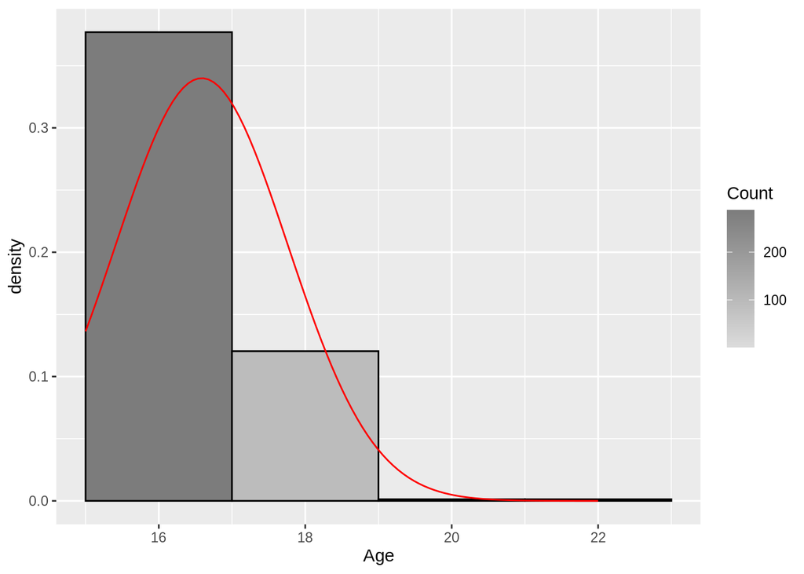

```r
gs <- ggplot(student, aes(x=age))
gs <- gs + labs(x="Age")
gs <- gs + geom_histogram(binwidth=2, colour="black", aes(y=..density.., fill=..count..))
gs <- gs + scale_fill_gradient("Count", low="#DCDCDC", high="#7C7C7C")
gs <- gs + stat_function(fun=dnorm, color="red",args=list(mean=mean(student$age, na.rm=TRUE), sd=sd(student$age, na.rm=TRUE)))
gs
```

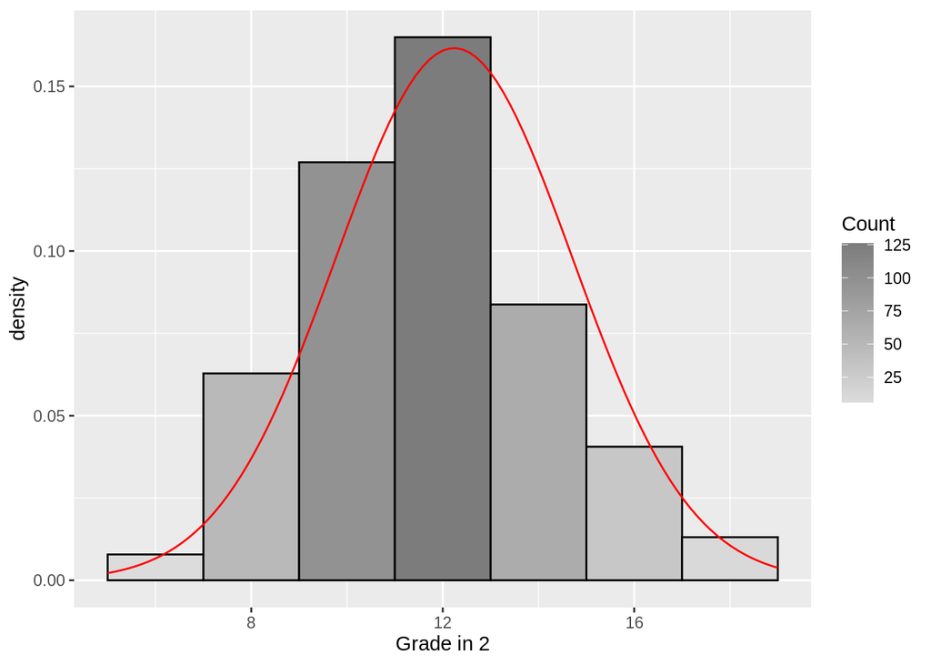

```r
gs <- ggplot(student, aes(x=pG2))
gs <- gs + labs(x="Grade in 2")
gs <- gs + geom_histogram(binwidth=2, colour="black", aes(y=..density.., fill=..count..))
gs <- gs + scale_fill_gradient("Count", low="#DCDCDC", high="#7C7C7C")
gs <- gs + stat_function(fun=dnorm, color="red",args=list(mean=mean(student$pG2, na.rm=TRUE), sd=sd(student$pG2, na.rm=TRUE)))
gs
```

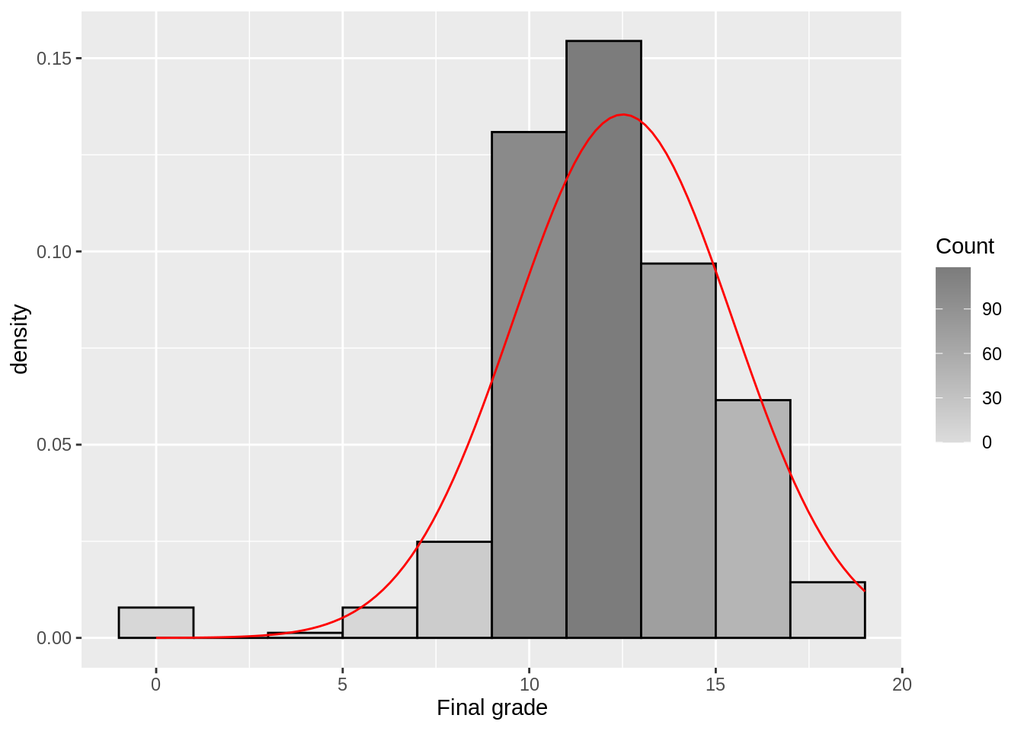

```r
gs <- ggplot(student, aes(x=pG3))
gs <- gs + labs(x="Final grade")
gs <- gs + geom_histogram(binwidth=2, colour="black", aes(y=..density.., fill=..count..))
gs <- gs + scale_fill_gradient("Count", low="#DCDCDC", high="#7C7C7C")
gs <- gs + stat_function(fun=dnorm, color="red",args=list(mean=mean(student$pG3, na.rm=TRUE), sd=sd(student$pG3, na.rm=TRUE)))
gs
```

Bar plot and pie charts are considered for nominal and ordinal data.

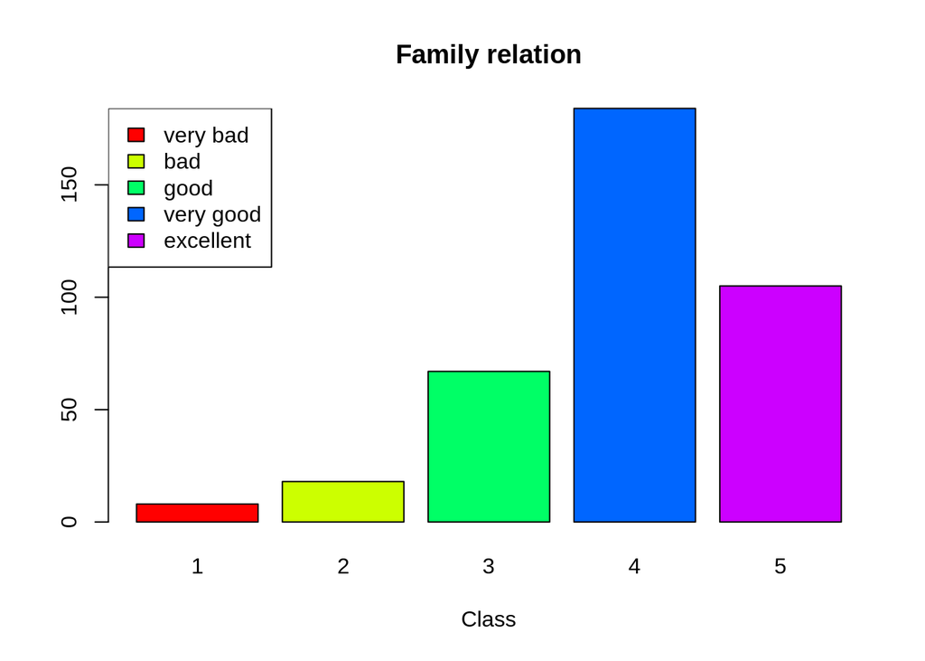

```r
barplot(table(student$famrel.p),
main = "Family relation",
xlab = "Class",
col=rainbow(5)
)
legend("topleft",
c("very bad","bad","good","very good", "excellent"),
fill = rainbow(5)
)
```

```r
x <- table(student$famrel.p)
labels <-  c("very bad","bad","good","very good", "excellent")

piepercent<- round(100*x/sum(x), 1)

cat("Percentage of students having different family relationships \n", piepercent,"\n")
```

```
## Percentage of students having different family relationships
##  2.1 4.7 17.5 48.2 27.5
```

```r
cat(" 1-5 indicates a scare from very bad to excellent")
```

```
##  1-5 indicates a scare from very bad to excellent
```

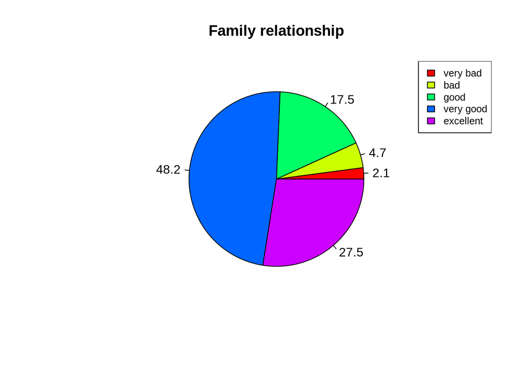

```r
pie(table(student$famrel.p), labels = piepercent, main = "Family relationship",col = rainbow(length(x)))
legend("topright", c("very bad","bad","good","very good", "excellent"), cex = 0.8,
   fill = rainbow(length(x)))
```

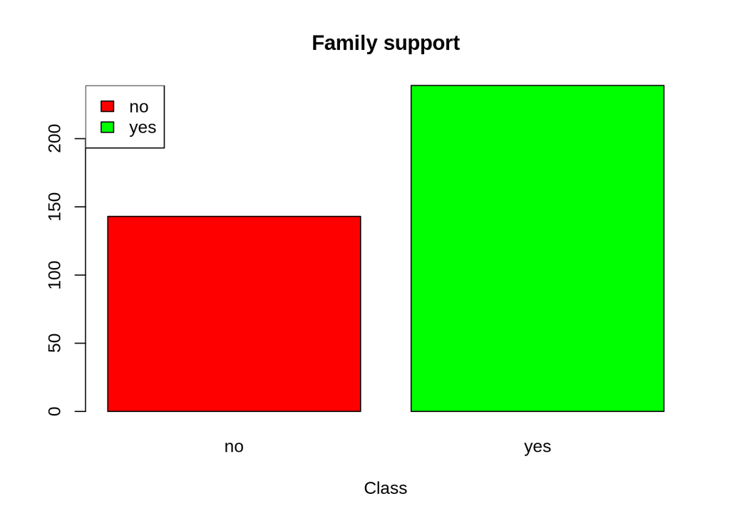

```r
barplot(table(student$famsup.p),
main = "Family support",
xlab = "Class",
col = c("red","green")
)
legend("topleft",
c("no","yes"),
fill = c("red","green")
)
```

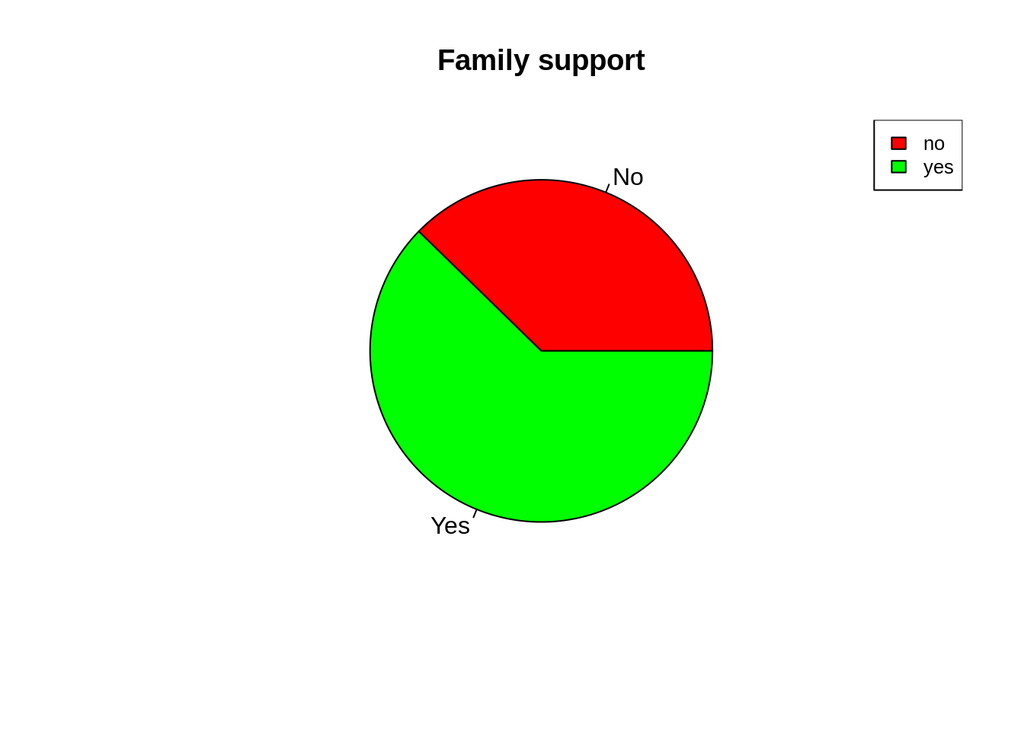

```r
x <- table(student$famup.p)
lbl <-  c("No","Yes")

pie(table(student$famsup.m), labels = lbl, main = "Family support",col = c("red","green"))
legend("topright", c("no","yes"), cex = 0.8, fill = c("red","green"))
```

**2. Assess at least one variable for normality**

Consider variable pG2 i.e. second period grade is it normally distributed.

Generating histogram

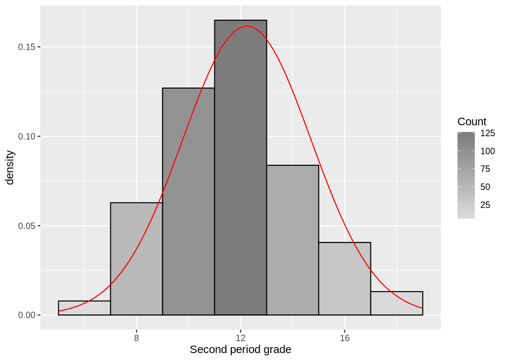

```r
#
gs <- ggplot(student, aes(x=pG2))
gs <- gs + labs(x="Second period grade")
gs <- gs + geom_histogram(binwidth=2, colour="black", aes(y=..density.., fill=..count..))
gs <- gs + scale_fill_gradient("Count", low="#DCDCDC", high="#7C7C7C")
gs <- gs + stat_function(fun=dnorm, color="red",args=list(mean=mean(student$pG2, na.rm=TRUE), sd=sd(student$pG2, na.rm=TRUE)))
gs
```

Generation of QQ plot

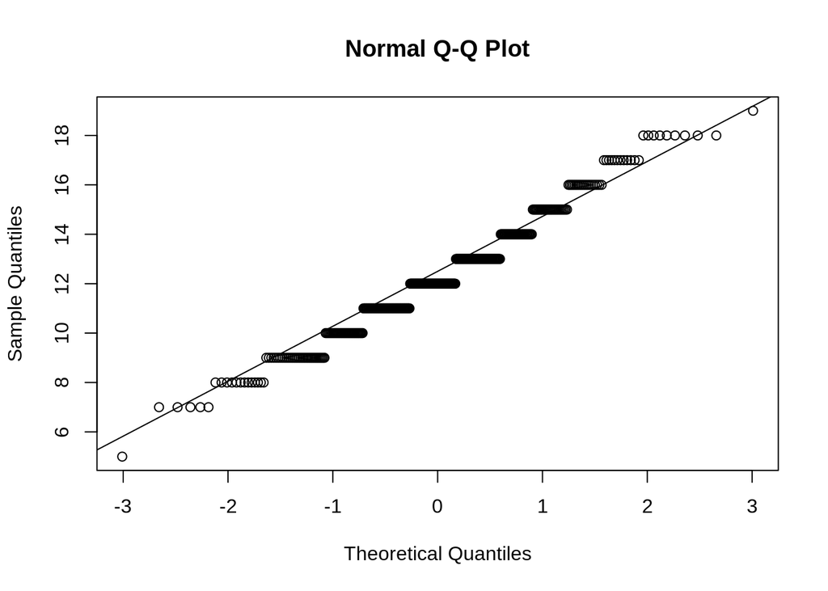

```r
#Create a qqplot

qqnorm(student$pG2)
qqline(student$pG2) #show a line on theplot
```

From the graph, it is slightly difficult to check whether the sample is normally distributed or not. So further analysis is done on the sample to assess the variable for normality.

```r
#stat.desc is a function from pastecs to desctibe the sample
pastecs::stat.desc(student$pG2, basic=F)
```

```
##       median         mean      SE.mean CI.mean.0.95          var      std.dev
##   12.0000000   12.2382199    0.1262913    0.2483153    6.0927086    2.4683413
##     coef.var
##    0.2016912
```

```r
#We can make our decision based on the value of the standardised score for skew and kurtosis
tpskew<-semTools::skew(student$pG2)
tpkurt<-semTools::kurtosis(student$pG2)
tpskew[1]/tpskew[2]
```

```
## skew (g1)
##  1.905089
```

```r
tpkurt[1]/tpkurt[2]
```

```
## Excess Kur (g2)
##      -0.7011438
```

```r
zpg2<- abs(scale(student$pG2))

FSA::perc(as.numeric(zpg2), 1.96, "gt")
```

```
## [1] 4.188482
```

```r
FSA::perc(as.numeric(zpg2), 3.29, "gt")
```

```
## [1] 0
```

We can see that skew value is 1.9 which is with in the range of acceptance level at .05 of of 95% of data. Since we have larger sample any value between +/-3.29 is also acceptable. Therefore, pG2 i.e. second period grade test is normally distributed.

*Report of normality:*

Second period grade was assessed for normality. Visual inspection of the histogram and QQ-Plot did not exhibhit any issues with skewness and kurtosis. The standardized score for skewness(1.91) and the standardized score for kurtosis (-0.70) was can be considered acceptable using the criteria proposed by West, Finch and Curran (1996). 100% of standardized scores for grade 2 fall within the bounds +/- 3.29, using the guidance of Field, Miles and Field (2013) the data can be considered to be a normal distribution (m=12.23, sd=2.47, n=382).

Now, let us check whether pG3 is normally distributed or not.

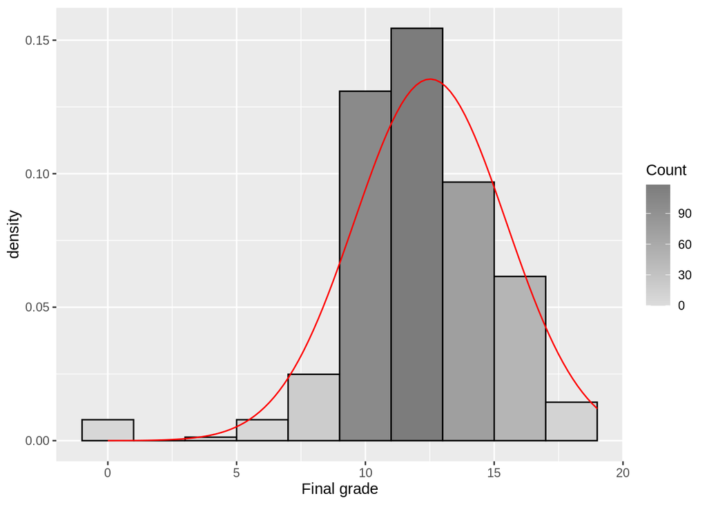

```r
#
gs <- ggplot(student, aes(x=pG3))
gs <- gs + labs(x="Final grade")
gs <- gs + geom_histogram(binwidth=2, colour="black", aes(y=..density.., fill=..count..))
gs <- gs + scale_fill_gradient("Count", low="#DCDCDC", high="#7C7C7C")
gs <- gs + stat_function(fun=dnorm, color="red",args=list(mean=mean(student$pG3, na.rm=TRUE), sd=sd(student$pG3, na.rm=TRUE)))
gs
```

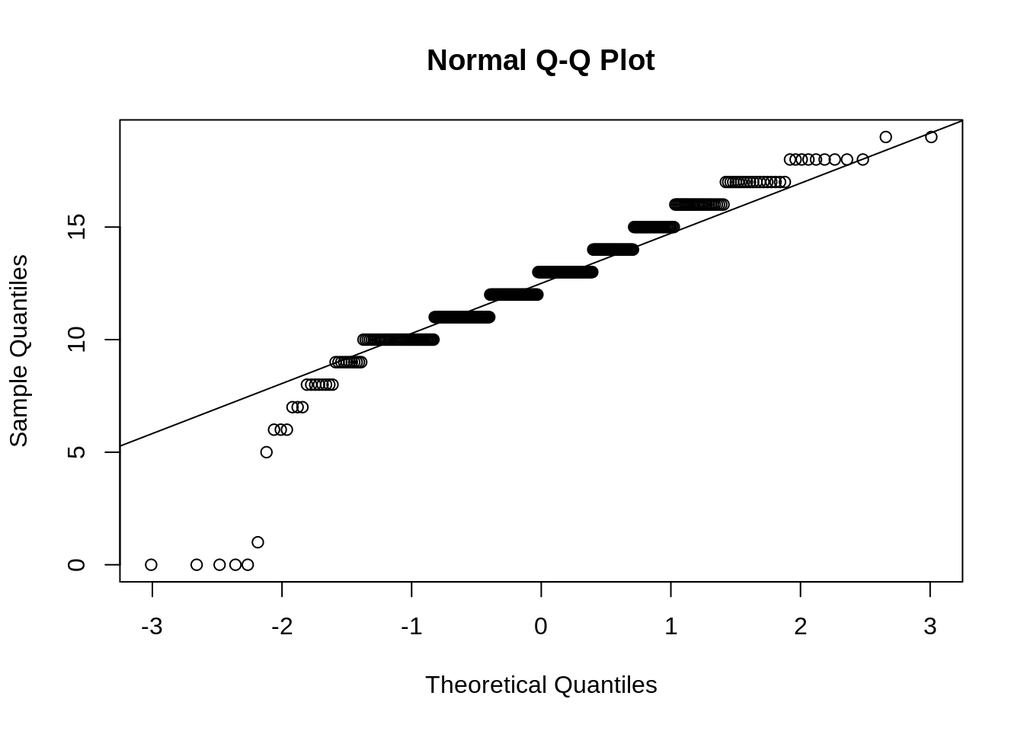

```r
#Create a qqplot
qqnorm(student$pG3)
qqline(student$pG3) #show a line on theplot
```

From the graph it is difficult know whether the sample for pG3 is normally distributed or not. So further analysis will help us to understand about whether the data is normally distributed or not.

```r
#stat.desc is a function from pastecs to desctibe the sample
pastecs::stat.desc(student$pG3, basic=F)
```

```
##       median         mean      SE.mean CI.mean.0.95          var      std.dev
##   13.0000000   12.5157068    0.1507017    0.2963112    8.6756057    2.9454381
##     coef.var
##    0.2353393
```

```r
#We can make our decision based on the value of the standardised score for skew and kurtosis
tpskew<-semTools::skew(student$pG3)
tpkurt<-semTools::kurtosis(student$pG3)
tpskew[1]/tpskew[2]
```

```
## skew (g1)
## -7.954719
```

```r
tpkurt[1]/tpkurt[2]
```

```
## Excess Kur (g2)
##         13.9035
```

```r
zpg3<- abs(scale(student$pG3))

FSA::perc(as.numeric(zpg3), 1.96, "gt")
```

```
## [1] 3.141361
```

```r
FSA::perc(as.numeric(zpg3), 3.29, "gt")
```

```
## [1] 1.570681
```

Skewness is -7.95 which is not in acceptable range. Now, we need to check how many percentage of outliers present in the dataset. Since the sample is larger than 80 cases we can use +/- 3.29 as threshold. There is 1.57% of sample outside +/- 3.29. So it not ok to consider data as normal.

*Repoting normality:*

Final grade was assessed for normality. Visual inspection of the histogram and QQ-Plot identified some issues with skewness and kurtosis. The standardized score for skewness (-7.95) and standardized score for kurtosis (13.90) can’t be considered acceptable using the criteria proposed by West, Finch and Curran (1996) as both values outside acceptable range. 98.43% of standardized scores for scores achieved in final grade fall within the bounds of +/- 3.29, using the guidance of Field, Miles and Field (2013) the data can be considered to not a normal distribution (m=12.51, sd=2.95, n=382).

**3. Identify some at least one correlation between your concepts of interest you want to investigate**

H0 : There is no relationship between student’s age and family support. H1 : There is a relationship between student’s age and family support.

Correlation test requires to understand distribution of both variables that is of interest.

Generating histogram

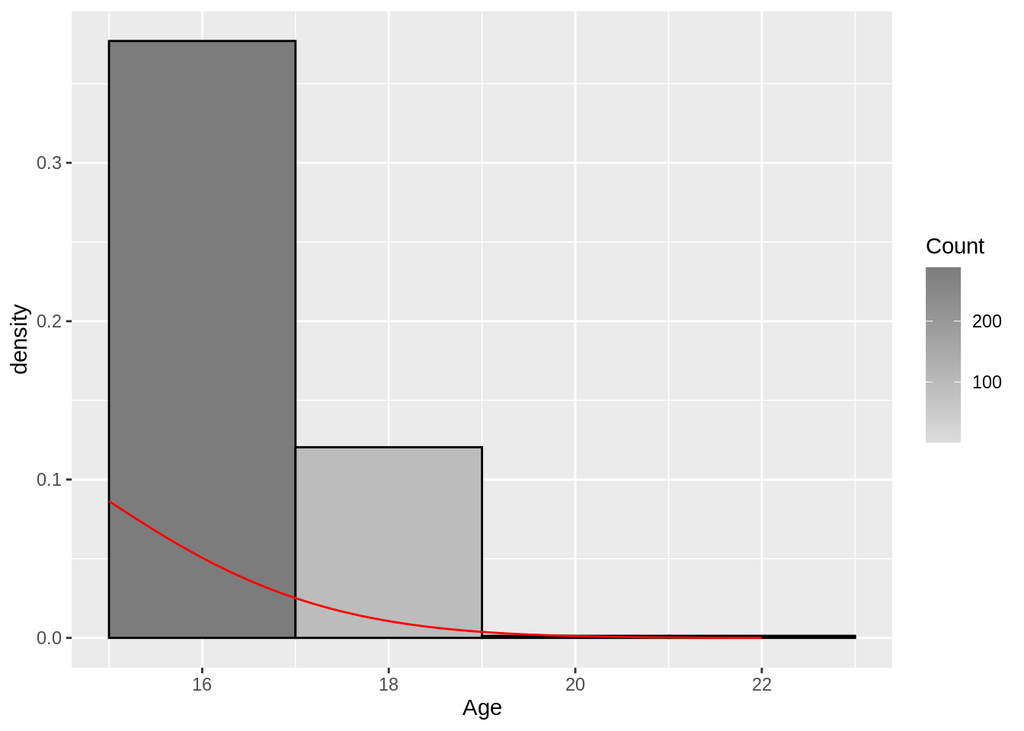

```r
gs <- ggplot(student, aes(x=age))
gs <- gs + labs(x="Age")
gs <- gs + geom_histogram(binwidth=2, colour="black", aes(y=..density.., fill=..count..))
gs <- gs + scale_fill_gradient("Count", low="#DCDCDC", high="#7C7C7C")
gs <- gs + stat_function(fun=dnorm, color="red",args=list(mean=mean(student$pG2, na.rm=TRUE), sd=sd(student$pG2, na.rm=TRUE)))
gs
```

Genetation of QQ plot

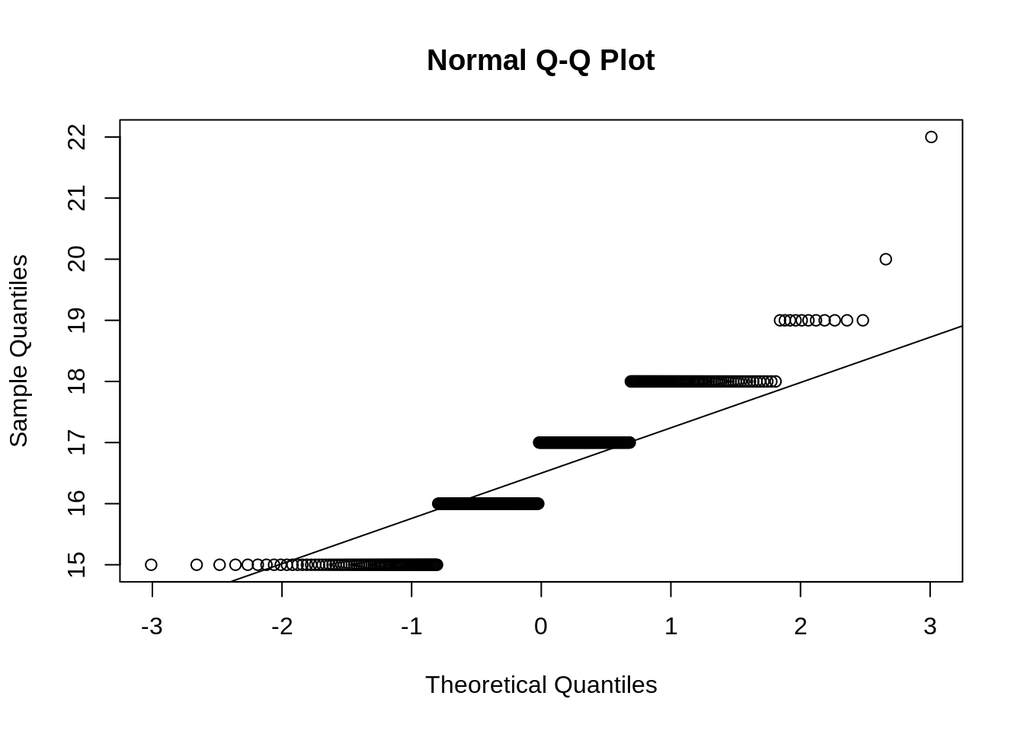

```r
#Create a qqplot
qqnorm(student$age)
qqline(student$age) #show a line on theplot
```

From the graph, it is difficult to conclude that the sample is normally distributed or not. So further analysis is done on the sample to assess the variable for normality.

```r
#stat.desc is a function from pastecs to desctibe the sample
pastecs::stat.desc(student$age, basic=F)
```

```
##       median         mean      SE.mean CI.mean.0.95          var      std.dev
##  17.00000000  16.58638743   0.06003995   0.11805115   1.37703206   1.17347009
##     coef.var
##   0.07074899
```

```r
#We can make our decision based on the value of the standardised score for skew and kurtosis
tpskew<-semTools::skew(student$age)
tpkurt<-semTools::kurtosis(student$age)
tpskew[1]/tpskew[2]
```

```
## skew (g1)
##  3.179405
```

```r
tpkurt[1]/tpkurt[2]
```

```
## Excess Kur (g2)
##       0.3905659
```

```r
zage<- abs(scale(student$age))

FSA::perc(as.numeric(zage), 1.96, "gt")
```

```
## [1] 3.403141
```

```r
FSA::perc(as.numeric(zage), 3.29, "gt")
```

```
## [1] 0.2617801
```

*Reporting*

Student age was assessed for normality. Visual inspection of the histogtram and QQ-plot identified some issues with skewness and kurtosis. The standardised score for kurtosis (0.39) can be considered acceptable using the creteria proposed by proposed by West, Finch and Curran (1996), but the standardised score for skewness (3.17) was outside the acceptable range. However over 99% of standardised scores for students age within the bounds of +/- 3.29, using the guidance of Field, Miles and Field (2013) the data can be considered to approximate a normal distribution (m= 16.58, sd=1.17, n=382).

The following code considers shapiro test for normal distribution.

H0: Age is normally distributed. H1: Age is not normally distributed.

```r
shapiro.test(student$age)
```

```
##
##  Shapiro-Wilk normality test
##
## data:  student$age
## W = 0.89877, p-value = 3.027e-15
```

Family support is nominal variable. We need not to check for normal distribution of the same, by nature categorical variables are not normally distributed.

Generating scatterplot

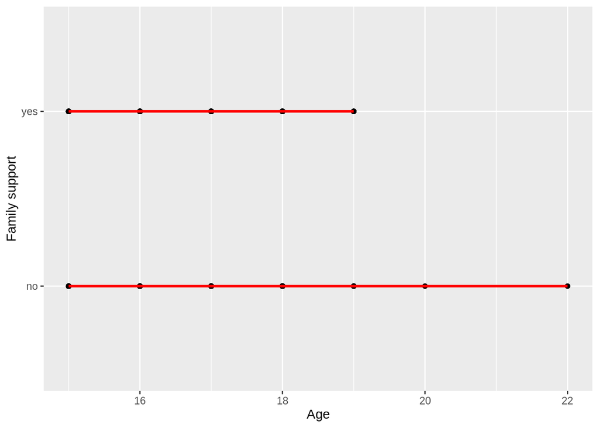

```r
#Simple scatterplot of feeling of control and perceived stress
#aes(x,y)
scatter <- ggplot(student, aes(age,famsup.p))

#Add a regression line
scatter + geom_point() + geom_smooth(method = "lm", colour = "Red", se = F) + labs(x = "Age", y = "Family support")
```

Since there are ties in the data considered, Kendall test is chosen for correlation test.

```r
famSupport <- ifelse(student$famsup.p=="yes", 1, 2)

cor.test(student$age, famSupport, method = "kendall")
```

```
##
##  Kendall's rank correlation tau
##
## data:  student$age and famSupport
## z = 2.2889, p-value = 0.02208
## alternative hypothesis: true tau is not equal to 0
## sample estimates:
##       tau
## 0.1063819
```

*Reporting*

The relationship between age and family support was investigated using a Kendall correlation. A weak positive correlation was found (tau =0.11, n=380, p=0.02).

Next example considers first grade(pG1) and second grade(pG2) for correlation.

H0 : There is no relationship between first period grade and second period grade. H1 :There is a relationship between first period grade and second period grade.

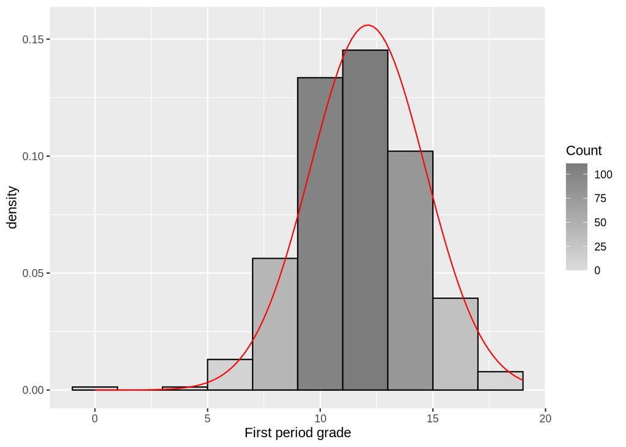

```r
gs <- ggplot(student, aes(x=pG1))
gs <- gs + labs(x="First period grade")
gs <- gs + geom_histogram(binwidth=2, colour="black", aes(y=..density.., fill=..count..))
gs <- gs + scale_fill_gradient("Count", low="#DCDCDC", high="#7C7C7C")
gs <- gs + stat_function(fun=dnorm, color="red",args=list(mean=mean(student$pG1, na.rm=TRUE), sd=sd(student$pG1, na.rm=TRUE)))
gs
```

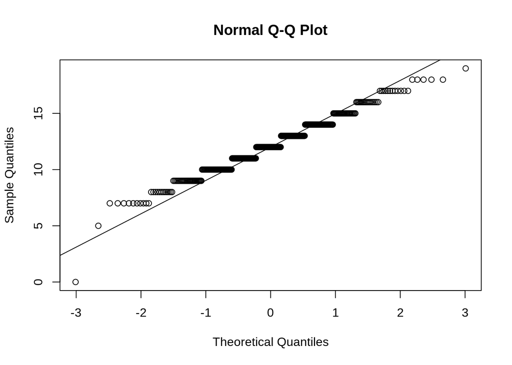

```r
qqnorm(student$pG1)
qqline(student$pG1)
```

```r
pastecs::stat.desc(student$pG1, basic=F)
```

```
##       median         mean      SE.mean CI.mean.0.95          var      std.dev
##   12.0000000   12.1125654    0.1308035    0.2571872    6.5358522    2.5565313
##     coef.var
##    0.2110644
```

```r
#We can make our decision based on the value of the standardised score for skew and kurtosis
tpskew<-semTools::skew(student$pG1)
tpkurt<-semTools::kurtosis(student$pG1)
tpskew[1]/tpskew[2]
```

```
## skew (g1)
## -1.225266
```

```r
tpkurt[1]/tpkurt[2]
```

```
## Excess Kur (g2)
##        2.966252
```

```r
zpg1<- abs(scale(student$pG1))
FSA::perc(as.numeric(zpg1), 1.96, "gt")
```

```
## [1] 4.712042
```

```r
FSA::perc(as.numeric(zpg1), 3.29, "gt")
```

```
## [1] 0.2617801
```

From the statistics we can conclude that pG1 i.e. first period grade is approximately normally distributed.

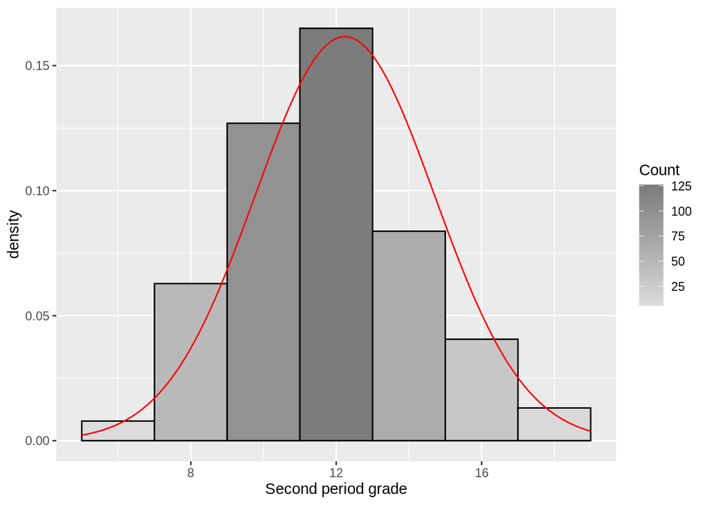

```r
library(ggplot2)
gs <- ggplot(student, aes(x=pG2))
gs <- gs + labs(x="Second period grade")
gs <- gs + geom_histogram(binwidth=2, colour="black", aes(y=..density.., fill=..count..))
gs <- gs + scale_fill_gradient("Count", low="#DCDCDC", high="#7C7C7C")
gs <- gs + stat_function(fun=dnorm, color="red",args=list(mean=mean(student$pG2, na.rm=TRUE), sd=sd(student$pG2, na.rm=TRUE)))
gs
```